# Labor market reform and innovation: Evidence from Spain

Converted from PDF `GarciaVega-LaborReformInnovation-2021-RP.pdf` · 17 pages · anchors: page `#pN`, block `#pN-bK`

Page 1

Research Policy 50 (2021) 104213

Available online 12 March 2021 0048-7333/© 2021 Elsevier B.V. All rights reserved.

### Labor market reform and innovation: Evidence from Spain

### María García-Vega <sup>a</sup>, Richard Kneller <sup>b</sup>, Joel Stiebale *<sup>,</sup><sup>c</sup>

a *School of Economics, University of Nottingham, University Park, Nottingham NG7 2RD, United Kingdom, GEP* b *School of Economics, University of Nottingham, University Park, Nottingham NG7 2RD, United Kingdom, GEP and CESIfo* c *Düsseldorf Institute for Competition (DICE), Heinrich-Heine University, Universitaetsstr. 1, 40225 Düsseldorf, Germany and GEP*

A R T I C L E I N F O

*JEL classification:* D22 J3 O31 G31

*Keywords:* Innovation New products Productivity Labor market reform EPL

A B S T R A C T

We analyze the effect of a labor market reform on firms’ product innovation. The reform, which amounts to a natural experiment, differentially reduced firing costs for some firms, thereby lowering adjustment costs in the presence of demand uncertainty. Using a difference-in-differences framework, we show that the reform increased product innovations. We also provide evidence that the reform induced upgrading of product quality and enabled firms to grow faster and enter new markets. The effects are concentrated in industries with high levels of demand volatility and R&D intensity, where flexible adjustments to unexpected shocks are important.

#### **1. Introduction**

The importance of innovation within theories of long run growth and development has generated considerable interest amongst economists and policy makers in understanding how various features of the policy environment affect innovation.<sup>1</sup>Traditionally, innovation policy has been focused on the role of intellectual property right protection, along with various tax and R&D subsidy schemes (Bloom et al., 2019; Bran stetter et al., 2006; Hall and Rosenberg, 2010). More recently, it has been recognized that labor market policies can also play a role.

Employment protection legislation (EPL) covers an array of policy instruments used to affect the flexibility of employment contracts and influence workers’ welfare and living standards.<sup>2</sup>Theory suggests that EPL may also affect innovation incentives, albeit with effects possible in opposite directions. If the demand for new products is uncertain and there are firing costs, firms may be less willing to take the risk of introducing innovative products to the market because they might be unable to downsize their labor force quickly if the demand of the new

products is lower than expected (Bartelsman et al., 2016; Mukoyama and Osotimehin, 2019; Saint-Paul, 1997; Samaniego, 2006). Therefore, in the presence of firing costs and uncertain demand, firms might be reluctant to innovate because they want to avoid the cost of discharging workers in the future.<sup>3</sup>An alternative possibility is that job security increases workers’, and therefore firms’, productivity along with the returns to innovation. For example, there is evidence that suggests that workers increase their training and investments in firm-specific skills when EPL protection is high (Belot et al., 2007; Boeri et al., 2017; Kahn, 2007). Consequently, restrictions on the firing of workers, by raising job protection, might work to increase the incentive of firms to innovate (Griffith and Macartney, 2014).

In this paper, we focus on the role of adjustment costs in determining innovation decisions, exploiting a change in EPL that differentially reduced the firing costs of small compared to large firms. As we will describe in detail below, this labor market reform amounts to a natural experiment. Our study is therefore distinct in that we provide, to our knowledge, the first causal evidence of the effects on product innovation

* Corresponding author. *E-mail addresses:* maria.garcia-vega@nottingham.ac.uk (M. García-Vega), richard.kneller@nottingham.ac.uk (R. Kneller), joel.stiebale@hhu.de (J. Stiebale). 1 See among others (Romer, 1990), (Grossman and Helpman, 1991), (Aghion and Howitt, 1992), and (Hall, 2007). 2 EPLs are a multi-faceted set of regulations that seek to alter the relative balance of power between firms and workers within the labor market and help to fix real, or perceived market imperfections.

3 According to Saint-Paul (1997) “to avoid paying the firing costs, the country with a rigid labor market will tend to produce goods with a relatively stable demand, at a late stage of their product life cycle, such as refrigerators”.

Contents lists available at ScienceDirect

## Research Policy

journal homepage: www.elsevier.com/locate/respol

https://doi.org/10.1016/j.respol.2021.104213 Received 28 April 2020; Received in revised form 29 January 2021; Accepted 1 February 2021

Page 2

*Research Policy 50 (2021) 104213*

2

from a EPL reform that reduced adjustment costs. Faced with demand uncertainty, even small changes in EPL can represent large changes in adjustment costs for small firms, raising the possibility that they responded particularly strongly to the increased flexibility provided by the reform we study. That it encouraged the employment of high skilled workers may also be used to indicate that a strong response to innova tion is likely. In addition, it is known that the incentive to undertake different types of innovation can differ in important ways for small, compared to the more commonly studied large firms. Akcigit and Kerr (2018) show that small firms are more likely to undertake exploration R&D in order to develop new products, whereas large firms are more likely to conduct exploitation R&D that seeks to improve the product lines they already serve. We use this to motivate our focus on the cre ation of new products. Having found a positive relationship between the reform and product innovation, we next investigate whether the effect is concentrated in firms that operate in uncertain and volatile sectors that require high flexibility, which is in line with the mechanism proposed by Saint-Paul (1997).

The period of EPL liberalization we exploit occurred in Spain in 2012. The reform allowed firms with fewer than 50 employees to hire additional workers (up to the 50 employee threshold) on permanent contracts for an extended trial period of up to one year. In pre-reform years, the maximum trial period was two months for unskilled workers and six months for skilled workers.<sup>4</sup>This new contract increased the flexibility with which treated firms could adjust the employment of these additional workers by reducing firing costs. Firms with more than 50 employees did not receive these benefits. We exploit the presence of a size threshold in a difference-in-differences regression, using the pre-reform size of the firm to identify treated firms, allowing us to capture intention-to-treat (ITT) effects.<sup>5</sup>To estimate local average treatment effects (LATE), we also conduct instrumental variable (IV) regressions. To further hone in on the mechanism that we study, we both report evidence of heterogeneity in innovation outcome across firms according to their industry and use a large number of robustness tests to rule out competing explanations. By doing so, we test the idea that new product innovations are more sensitive to EPL reforms in uncertain environments where flexibility is of greater importance.

Our main finding confirms the prediction that a reduction in EPL encourages new product innovations by small firms. Our estimates of intention-to-treat effects indicate an increase in the number of product innovations of between 0.25 and 0.3 amongst treated firms (defined by pre-reform size) relative to a control group in the post-reform period. These effects are economically important as the average rate of product innovation per year is 0.7. These results are robust to the addition of controls, including allowing for different exposures to geographic and sectoral shocks across treatment and control group.

Consistent with the idea that adjustment costs matter for innovation, we show that the effects of the labor market reform are concentrated in industries with high demand volatility and high R&D intensity. This suggests that the reform induced innovation amongst firms where employment flexibility and a reduction in adjustment costs are likely to have their strongest effects. It is unlikely that such a heterogeneity

across industries would arise if the reform induced innovation through a different mechanism such as e.g. improved screening of workers by firms. Additional investigation of the data indicates that this EPL reform encouraged investment in capital equipment and an upgrading of product quality, further supporting this interpretation. We also find no evidence of a significant effect on physical TFP, indicating that the capital investment induced was not directed towards reducing produc tion costs. This is consistent with the prediction that the creation of new products is an important feature of small firm innovation. Moreover, we show that treated firms grow faster, are more likely to enter new in ternational markets and undertake complementary investments in human capital and R&D planning. All these suggest that the reform reduced firms’ adjustment costs, which induced firms to innovate and undertake other risky investments.

Our study is related to the literature on labor market institutions and economic performance (Freeman, 2005). Within this there is a large empirical literature on the effects of EPL on employment (see the survey by Boeri et al., 2015).<sup>6</sup>More directly, we contribute to the literature focused on the innovation effects of EPL and labor regulations. A slightly older strand of this uses industry-level data across countries or variation in legislation across US states. Acharya et al. (2013) find for example that stronger dismissal laws had a positive impact on innovation in tensity and led to more innovation in innovation-intensive industries. Barbosa and Faria (2011) finds the opposite effect for a broader measure of EPL, but using country-industry data. The use of country or industry level data has the disadvantage that it is difficult to account for unob servable characteristics of countries, industries and firms that determine innovation, undermining claims of causation (Griffith and Macartney, 2014). To deal with these endogeneity problems, a more recent approach has been to turn to the use of firm level data. Pioneering work here in cludes (Griffith and Macartney, 2014) and (Acharya et al., 2014) who focus on innovation by large firms. Griffith and Macartney (2014) explore the relationship between EPL and innovation behavior within subsidiaries of multinationals (MNEs) across different countries. Their results indicate that MNEs locate more innovative activity in countries with high EPL, but more radical innovation activity in countries with low EPL. That their measure of EPL also has no time variation that can be exploited for identification compares to our paper and with Acharya et al. (2014), who focus on EPL within a single country. Acharya et al. (2014) explore variation in the adoption of wrongful dismissal legisla tion across US states along with data on the granting of patents and ci tations. They argue that wrongful dismissal legislation affects holdup problems between firms and innovating employees. A disadvantage of their empirical setting is that the strongest effects occur from differences in the timing of EPL provisions across just 13 states, where the date of adoption differed by as much as 30 years. Anticipation effects would therefore seem possible. In contrast to them, our focus is on the effect of EPLs on adjustment costs. A further novelty of our analysis is that we provide evidence of a reform that was unlikely to be anticipated.

A separate approach of identification is offered by Aghion et al. (2021), who analyze how size thresholds related to employment regu lations affect innovation incentives during periods of demand volatility. They focus on how such a threshold reduces incentives for firms to innovate since firms are reluctant to grow above a size threshold when labor laws become stricter. In contrast, our paper focuses instead on a change in employment protection and we exploit a size threshold to identify the effects on innovation from the variation in adjustment costs across firms.

Finally, a smaller number of micro-level studies have focused on the effect of EPL on productivity. For example, Autor et al. (2007), using the adoption of wrongful-discharge protection by state courts in the US, find

4 Gamberoni et al. (2016) analyze employment effects of this liberalization period. However, they focus on a different aspect of the broader reform pack age, employment subsidies. They do not find robust evidence that these sub sidies had an effect on employment growth.

5 Reform-specific size thresholds are often exploited within a regression discontinuity design (RDD). However, in our application firms just below the size threshold are unlikely to benefit significantly from the reform as the new contracts applied only to the marginal worker. For instance, a firm with 49 employees would only be able to hire one additional worker with the new type of contract. We also provide empirical evidence that firms just below 50 em ployees did not respond strongly to the reform in Fig. 1. We discuss this figure in more detail later in the paper. As we discuss in Section 4, our results are unlikely to be driven by firm size manipulation around the cut-off.

6 A common finding across this literature is that EPL reduces job turnover, although the effects differ across type of workers and the specific aspects of EPL.

*M. García-Vega et al.*

Page 3

*Research Policy 50 (2021) 104213*

3

that there is a negative relationship between EPL and total factor pro ductivity (TFP). Similarly, Bassanini et al. (2009) find a negative effect of EPL on industry-level TFP for OECD countries. More recently, Bjuggren (2018) studies the effect of a Swedish EPL reform that differ entially affected firms of different size. He finds that the reform lead to a rise in labor productivity.

To summarize our contributions. First, we provide evidence on a particular form of EPL; the extension of trial periods that took place in an unanticipated way. This enables us to provide causal evidence on the relationship between innovation of a particular type of EPL. Second, that the reform we study captures only one type of EPL allows us to zero in on a key mechanism behind the theoretical relationship between innova tion and EPL, namely flexibility in employment contracts, reducing adjustment costs. We also show that these can help firms in volatile and R&D intensive environments. This result supports theoretical arguments by Saint-Paul (1997). Third, in addition to the innovation effects of EPL, we contribute to the productivity literature through the ability to separate changes in revenue productivity from those that occurred to prices and physical quantities, allowing us to study physical TFP. The increase in prices and costs of materials that we find after the reform supports models that relate increases in quality of existing products after a reduction in firing costs (Mukoyama and Osotimehin, 2019). Fourth, our results have implications for public policy, in particular to support calculations of the benefits and costs of EPL.

The rest of the paper is organized as follows. Section 2 summarizes our main hypotheses which we aim to test in the empirical analysis. In Section 3, we describe the Spanish labor market and the reforms that occurred in 2012. Section 4 describes the data and the empirical strategy that we use in the paper. We describe the empirical results in Section 5 and we perform a large battery of robustness checks. In Section 6, we study whether the main channel that drives our results is the increase flexibility in the labor market. In Section 7, we show the effect of the reform for alternative outcome variables. Section 8, we calculate the magnitude of our effects and discuss the implications of our results for economic policy. Section 9 concludes.

#### **2. EPL and innovation**

Innovation is an activity that typically generates more uncertain returns than investment in tangible assets (e.g., Amoroso et al., 2017) and requires more significant adjustment to the organisation of pro duction and the workforce (Griffith and Macartney, 2014). Depending on the success of innovation activity, firms might be induced to down size and fire employees or face incentives to expand production and hire new workers. Furthermore, as implementing an innovation often re quires different types of human capital and makes old production pro cesses obsolete, firms might aim to replace old workers with new tasks by laying off existing employees and hiring new workers on the external market (Bassanini and Ernst, 2002). These adjustment are costly and the higher the adjustment costs, the lower the expected returns from inno vation activity. A high level of EPL increases the costs of both down sizing and expanding the existing workforce (e.g., Pissarides and Mortensen, 1999). Hence, we expect that a reduction in EPL via a labor market reform increases the incentives to introduce new products (Hy pothesis 1).

The effects of EPL on innovation are likely to be heterogeneous across industries. Results of innovation activities typically require ad justments in both firms’ capital and the workforce. As EPL affects the costs of adjusting employment, it is likely to matter more if labor costs are a significant share of firms’ production costs. We therefore expect that the effects of the employment reform on innovation are concen trated in sectors with high labor share, i.e. a high ratio of wage costs to physical investment (Hypotheses 2).

The degree of desired expansion or downsizing of the workforce depends on the outcome of innovative activity. The expected adjustment costs are most significant in the case of extreme outcomes, whether

positive or negative. It is therefore most likely that labor market rigid ities hold up innovation activity in an environment where volatility is high.<sup>7</sup>If an EPL reform affects innovation via adjustment costs, we expect the effects of the reform to be concentrated in industries where the volatility of sales and employment is high (Hypothesis 3).

#### **3. Institutional background and labor market reform**

*3.1. The Spanish labor market and its dismissal costs*

Before turning to the details of the labor market reform, we sum marize the main features of the Spanish labor market that are relevant for our study. On average, the costs of dismissal in Spain are high (OECD, 2013a). For example, an employee with 20 years of tenure in his job would receive 30 months of wages in case of unfair dismissal (12 monthly wages in case of fair dismissal).<sup>8</sup>This compares with 13.7 months of wages in a case of unfair dismissal for an employee with the same tenure for the average OECD country. Employees on a fixed-term contract have a severance payment which is equal to 12 days of salary per year of service at the end of his contract or when the task for which they have been hired finishes. In case of unfair dismissal, fixed term contract workers receive the same severance payment as workers with permanent contracts.<sup>9</sup>

An important and differential characteristic of firing behavior within the Spanish labor market is that the large majority of firms dismiss workers by declaring the dismissal to be unfair. The primary reason is to avoid legal costs if workers sue the firm (typically these legal costs are paid by the firm, see García-P´erez et al., 2018). Spanish labor courts rule in three-quarters of cases that the dismissals are unfair (Bentolila et al., 2012). This implies that, before the reform, employees with one year of tenure would typically have received 45 days of salary as severance payment, independently on their type of contract. Following the reform, no such payments were necessary. We further note that very few OECD countries have any severance payment for contracts shorter than one year.

*3.2. The reform*

The Great Recession beginning in 2008, soon followed by the Spanish sovereign debt crisis in 2010, affected the Spanish economy badly. In 2010, GDP per capita fell by 4.9% while the unemployment rate rose to 20.1% (for the young population this rate was 41.5%). As a response to these economic woes, in February 2012 the Spanish Gov ernment approved a deep labor reform, with the intention to reduce the

7 See Czarnitzki and Toole (2011) for an analysis of the effects of uncertainty on R&D in general. Cu˜nat and Melitz (2012) predict that countries with low degree of labor market regulation develop a comparative advantage in in dustries with high sales volatility.

8 For contracts signed before 12 February 2012, contracts have a severance payment of 45 days of salary per year of job tenure with a maximum of 42 months in case of unfair dismissal. After that date, the severance payment for contracts under unfair dismissal is equal to 33 days with a maximum of 24 months. In case of fair dismissal, the severance payment is 20 days of salary per year with a maximum of 12 months. Firms with less than 25 employees have to pay 60 percent of severance payment in case of fair dismissal. The other 40 percent is paid by a Governmental Wage Guarantee Fund (OECD, 2013b).

9 The Spanish labor market has two main types of contracts: permanent and fixed-term contracts. In 2010, the first year of our main estimation sample, the share of fixed-term contracts was 24.7 percent. This large number is partly due to the large size of the service sector and in particular the importance of the tourist industry in Spain, which is very seasonal (Source: Spanish National Institute of Statistics). The share of fixed-term contracts is much smaller for the manufacturing sector. For example, in our representative sample of the manufacturing sector, the share of fixed-term workers is 9.4 percent for the year 2010.

*M. García-Vega et al.*

Page 4

*Research Policy 50 (2021) 104213*

4

rate of job destruction and to generate employment. The economic logic behind the reform was to increase the internal flexibility of employment within firms so that they could adjust to the recession (Bentolila et al., 2012). There is a general consensus that the details of the reform were not anticipated by firms (OECD, 2013a). The reform occurred as the result of a change in government in November 2011 and was not dis cussed during the political campaign. The reform was instead first mentioned in the inaugural address of the Prime Minister at the end of December 2011.

The new contract increased employment flexibility as it could be used as a one-year contract without severance payments if it led to dismissal within the trial period. Moreover, the contract allowed firms to freely dismiss employees without providing justification for doing so during the first year. Note that all OECD countries, with the exception of the United States, require that firing be justified (Jimeno Serrano et al., 2015). In terms of cost savings for the firm, this included up to 45 days of salary as a severance payment plus litigation costs and interim salaries that typically followed from separations under the previous form of EPL. In Spain, companies that dismiss employees before the contract ends expect that the employee will claim that the dismissal is unfair and start

a litigation process (G´omez Abelleira, 2012). This entails costs for the company in terms of interim salaries and litigation costs.<sup>12</sup>Therefore, from the point of view of the firm, the *contrato de emprendedores* elimi nated severance payment, saved time, allowed them to avoid litigation costs and reduced uncertainty related to the hiring process. The contract also provided companies with an annual subsidy of 1100 euros on average per worker over a period of three years.<sup>13</sup>

Other elements of the 2012 labor market reform applied to all firms and included no specific size thresholds. These changes included the following: a) decentralization of collective bargaining agreements;<sup>16</sup>b) new definition of the causes for fair dismissal; and c) a reduction of severance payment in case of unfair dismissal for permanent contracts,

**Table 1** Descriptive statistics.

[output not shown]

NOTE: table converted from PDF layout to HTML text; cell boundaries are reconstructed. See PDF if exact alignment matters.

Note: This table shows the descriptive statistics of the main variables for firms with less than 50 employees and for firms with at least 50 employees. The *Number of products innovations* is the yearly number of completely new products, or with such modifications that they are different from those produced earlier; *Exports share* is the ratio between total exports over sales; *Capital goods for product innovation* is the natural logarithm of the investments in capital goods for product improvement; *Organizational labor innovation* is a dummy variable that takes the value one if a firm has introduced new ways to organize working routines or the organization of new responsibilities; *Number of markets* is the number of markets where the company operates; *TFP* is the Total Factor Productivity calculated as the residual from a production function following (Ackerberg et al., 2015).

10 There are two exceptions to the probation time explained above. The first exception is for companies with less than 25 employees that have a probation time of three months. The second exception is for temporary contracts with a duration of less than six months that have a probation time of one month (unless specified in the collective bargaining agreement).

11 Civil-law OECD countries include those with French civil-law: Belgium, France, Greece, Italy, Luxemburg, Mexico, the Netherlands, Portugal, Spain, Turkey; countries with German civil-law: Austria, the Czech Republic, Estonia, Germany, Hungary, Japan, Korea, Poland, the Slovak Republic, Slovenia, and Switzerland; and countries with Nordic civil-law: Denmark, Finland, Iceland, Norway, and Sweden (OECD, 2013c).

12 The interim salary is the salary from the date of dismissal to the date of the Court’s judgement notification. This interim salary is paid by the company and it is, on average, three to six months of salary. In Spain, the litigation costs are typically paid by the employer G´omez Abelleira (2012) and they are relatively high.

13 Gamberoni et al., 2016 analyze the impact of this subsidy on employment growth but they do not find any significant effects.

14 This information is available at https://www.sepe.es/HomeSepe/que-es-e l-sepe/estadisticas/contratos/emprendedores.html and at https://www.sepe. es/HomeSepe/que-es-el-sepe/estadisticas/contratos/estadisticas-nuevas.html

15 The OECD analysed the effect the *contrato de emprendedores* in its assess ment of the Spanish labor reform of 2012 (OECD, 2013a). The OECD provided evidence that this contract generated hiring incentives and suggested that it might disincentivize litigations in Court.

16 The reform gave priority to the collective bargaining agreements at the firm level over those at the industry or regional level. In addition, it also made easier for firms to opt-out of higher-order agreements. However, the use of this opt-out option was low in the recent post-reform period. For example, Izquierdo and Jimeno (2015) report that only 3.4% of firms opt-out from collective agree ments in 2013.

*M. García-Vega et al.*

Page 5

*Research Policy 50 (2021) 104213*

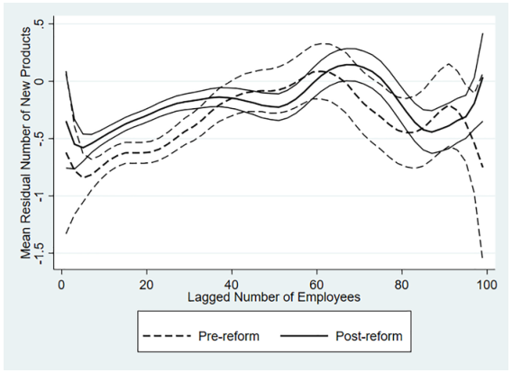

NOTE: figure/graphic rendered as an image from the PDF; its content is not machine-readable text. Caption (if any) follows as the next block.

5

with the intention of decreasing the EPL gap between permanent and fixed-term contracts.

#### **4. Data, variables and empirical strategy**

*4.1. The data and the main variables*

In this section, we describe the dataset and the main variables that we use for our empirical analysis. Further details are in the following sections and in Table 1 where we present descriptive statistics and definitions of the main variables by treatment status. The data we use is from the Encuesta Sobre Estrategias Empresariales (ESEE).<sup>17</sup>This

dataset, funded by the Spanish Ministry of Industry, is a representative survey of Spanish firms in the manufacturing sector. Around 1800 firms are surveyed every year. The initial sample selection of the survey is based on all firms with more than 200 employees (with a response rate of 70%) and a random sample by industry and size strata of 5% of all firms with up to 200 employees. Newly created firms are added every year to the survey, such that the representativeness of the sample is maintained over time.

Our sample is an unbalanced panel of 1766 firms from 2010 to 2015, with an average of five observations for each firm. In the survey, firms provide information on sales, number of employees, changes in prices of inputs and final goods and information on innovation outputs along with information on other indicators of product upgrading. Table A.1 in the Appendix depicts the industry composition of our sample. As Table A.2 in the Appendix shows, the geographical distribution of firms is repre sentative of the regional economic activity of the Spanish economy. Approximately half of firms in our sample are located in the regions of Catalonia, Madrid, Comunidad Valenciana and Basque country. The

other half of the firms in our sample are distributed across different regions reflecting their economic size. The size distribution of firms in our sample is depicted in Table A.3.

Our principal measure of innovation output is the number of product innovations that a company has obtained in a given year. Product in novations are defined in the survey as: *“Completely new products, or with such modifications that they are different from those produced earlier.”* The number of new products as measure of innovation output has been previously used in the innovation literature (e.g., Fernandes and Pau nov, 2012; Guadalupe et al., 2012; Harrison et al., 2014; Raymond et al., 2010). Guadalupe et al. (2012) also consider that product innovations per year can be interpreted as the change in a firm’s product innovation stock. In our context, product innovations also link with the theory of Saint-Paul (1997), where product innovations (or introduction of new goods) are likely to be sensitive to demand uncertainty and thus to firing costs. Another advantage of focusing on product innovations in our application is that they occur frequently for small and large firms, albeit where their number increases on average with the size of the firm. On

**Fig. 1.** Pre- and Post-reform product innovations. Note: Figure 1 plots fitted values and 90 percent confidence intervals from a local polynomial regression. The outcome variable is the mean residual of the number of new products obtained by estimating a two-way fixed effects model of the number of product innovation that includes firm and year effects. The explanatory variable is the lagged number of employees.

**Table 2** Difference-in-differences of means for different employment measures.

[output not shown]

NOTE: table converted from PDF layout to HTML text; cell boundaries are reconstructed. See PDF if exact alignment matters.

Note: *Employees* is the natural logarithm of the average number of employees; *Hours worked* is the natural logarithm of the average number of hours worked; *Overtime* is the average overtime worked in the company, measured in hours. Standard errors are in parentheses. * *p <* 0*.*10*,* ** *p <* 0*.*05*,* *** *p <* 0*.*01

17 Details on EESE dataset and data access guidelines can be obtained at: htt p://www.fundacionsepi.es/investigacion/esee/en/spresentacion.asp. Recent papers using this dataset include (Doraszelski and Jaumandreu, 2013), Dor aszelski and Jaumandreu (2018) and Guadalupe et al. (2012) among others.

*M. García-Vega et al.*

Page 6

*Research Policy 50 (2021) 104213*

6

We use the number of product innovations for our baseline specifi cations and alternative outcomes in Section 7. These include measures important within quality upgrading such as imports of technology and investments in capital for product improvement. Our data also provide information about other firm outputs that might face high demand un certainty. In particular, we know the number of geographical markets where a firm sells its products and the volume of exports. We consider traditional measures of firm outputs such as sales and quantity growth. We also use for our analysis information about prices for final goods and materials to construct measures of physical total factor productivity (TFP). We describe the construction of physical TFP in Section 7. The descriptive statistics in Table 1 show that firms with fewer than 50 employees differ from larger firms along several dimensions including: lower physical capital investments, lower export shares, smaller number of geographical markets, and lower productivity.

Before explaining our empirical methodology, we first confirm that the EPL reform of interest affected employment decisions. We report the difference-in-difference of means between firms with fewer than 50 employees in 2011 (the year before the reform) and larger firms. We report these for years before and after the reform for several employ ment related variables. We present these results in Table 2. In the table, we include the natural logarithm of the number of employees, employment growth, the natural logarithm of the number of hours worked (and its growth) and reported overtime (and its growth). For all variables, there is a statistically significant increase in the treatment group relative to the control firms after the reform. For example, the average yearly employment growth rate of the treated firms increases by about 2.2 percent relative to unaffected firms, while the growth rate of working hours increased by 1.7 percent. These numbers suggests that firms modified their hiring behaviour after the policy change in ways consistent with the ambitions of the reform and with expectations.

Initial evidence on an effect from the reform on product innovation can be seen in Fig. 1. To generate this figure we first estimate a linear regression of the number of product innovations on a full set of firm and year fixed effects. This regression is estimated separately for the pre- reform (2010 and 2011) and the post-reform time periods (2012 to 2015). We then derive the residuals from these two regressions. Finally, we plot a local polynomial regression of the residuals against the lagged number of employees. The figure therefore shows how the number of product innovations differs over the firm size distribution in the pre- and post-reform time periods. As is evident in Fig. 1, amongst firms in the treated group of firms with initially fewer than 50 employees, the mean residual is larger in the post-reform than in the pre-reform period. This indicates that there were more product innovations post-reform for these firms and provides initial evidence that innovation increased for these firms because of the policy change. Fig. 1 also suggests that this increased innovation response is not driven by firms close to the threshold of 50 employees, indeed there is a mild decrease in innovation for firms close to the threshold. Instead, the positive effects are concentrated among firms between 10 to 35 employees, which are the firms that were provided the greatest opportunity to hire a greater number of employees on the *contrato de emprendedores* contracts.<sup>18</sup>

Importantly, it is also apparent from this figure that for firms that were above the 50 employee threshold, the number of innovations did not change over time.

*4.2. Empirical strategy*

To study the effect of a reduction on EPL on firm innovativeness, we estimate a difference-in-differences (DID) model, where we take advantage of the size threshold of the reform. The differences in within- firm changes in innovation between treated and control firms can be expressed as follows:

*yit* = *α*0 + *β Ti* + *θ Ti* × *Postt* + *δt* + *εit.* (1)

In Eq. (1), the variable *yit* represents the innovation outcome of firm *i* in period *t, α*0 is a constant term, *Ti* is a time-invariant treatment indicator which takes value one if employment in 2011, the year before the re form, was below 50. *Postt* is a dummy variable that takes the value of one in all post-reform periods (2012–2015), *δt* includes a full set of time dummies and *εit* is an error term. Our term of interest is the interaction term *Ti* × *Postt,* with the estimated *θ* coefficient, which is the DiD parameter of interest and measures the intention-to-treat (ITT) effect. If the estimated *θ* coefficient is positive, it would indicate that a reduction in EPL (through a decline in firing costs) increases innovation. Standard errors are adjusted for clustering at the firm level. We restrict our main estimation sample to the years 2010 to 2015 to focus on a relatively narrow time window around the reform. However, we also report some additional results for earlier years.

Since the main goal of our analysis is to investigate the effect of the labor market reform on innovation and how this effect varies across different types of firms and industries, we extend Eq. (1) to allow for firm-specific unobserved heterogeneity (*αi*), and add in some specifica tions a vector of firm characteristics including initial size, age and size growth, as in the following equation:

*yit* = *αi* + *θ Ti* × *Postt* + *β Xit* + *δt* + *εit* (2)

A potential concern is that *θ* might be capturing differential trends be tween treated and control groups. Controlling for this issue is particular relevant in our case, because it is possible that the treated group, which are small firms, would grow faster than the control group independently of the reform. For this reason, we conduct placebo tests for different thresholds of firm size. Moreover, in addition to results where we restrict our sample to firms of similar pre-reform size, we include in our model firm-specific growth paths as in a correlated random trend model (e.g., Bøler et al., 2015):

*yit* = *αi* + *θ Ti* × *Postt* + *gi* × *trendt* + *β Xit* + *δt* + *uit* (3)

where *trendt* denotes a linear time trend. We take first differences of equation (3). This yields the following equation, which we estimate by OLS with firm fixed effects:

Δ*yit* = *θ* Δ(*Ti* × *Postt*) + *gi* + *β* Δ*Xit* + Δ*δt* + Δ*uit* (4)

We use Eq. (4) to analyse changes in the product innovation stock across time. Thus, we use the number of new product innovations in a partic ular year as our measure of Δ*yit* in equation (4).<sup>19</sup>

It might be tempting to exploit the size threshold of the reform using a regression discontinuity design. However, in our case, and as shown in

18 We discuss the possibility that firms may choose to remain below the threshold of 50 employees and the effect that this may have on innovation in Section 8.

19 Note that this specification is equivalent to estimate equation (2) if the outcome variable is defined as product innovation flow instead of product innovation stock.

*M. García-Vega et al.*

Page 7

*Research Policy 50 (2021) 104213*

7

Fig. 1, regression discontinuity is not a useful methodology because firms just below the size threshold benefit little from the policy change as they can only exploit the change induced by the reform until they cross the size threshold. For example, a firm with 49 employees could only hire one additional worker using a *contrato de emprendedores*. However, as we discuss in the results section, our results are robust to limiting the estimation sample to firms with initial size that is not too far away from the threshold, i.e. firms with more than 30 and/or below 70 employees in the pre-reform year.

#### **5. The effects of the reduction of EPL on innovation**

*5.1. Baseline results*

In this section, we turn to the analysis of the reduction of EPL pro tection on innovation. Table 3 presents our core results of the effect of the reform on product innovation. Across the table, we estimate Eq. (4) adding different combinations of firm fixed effects, year dummies, industry-year and region-year fixed effects and additional controls that include initial size, age and size growth. We use this to demonstrate the robustness of our main finding to the addition of a range of covariates. Throughout the table the results suggest a strong and positive effect of a reduction of EPL protection on new product innovation. The treatment coefficient is positive and statistically significant at standard levels. This implies that there is a significant increase in the number of product in novations for the treated firms in the post-reform period as compared to the control group. The estimated coefficients range from 0.26 to 0.3 per year in the different estimations. Since the average number of product innovations per year is 0.7, the effects are quantitatively important. They imply an increase in the innovation rate for the treated group by approximately 37%. While these estimated effects may appear large, further investigation of the product innovation data amongst treated firms showed noticeable increase in zero to one, and from one to two, new product innovations in the post-reform time periods. The percent age increase in the number of product innovations for treated firms implied by these estimated is therefore large, but from an initially small number.

Comparing columns (1) and (2) to those in columns (3) to (6), the results are robust to controlling for firm-specific trends in the innovation stock. There is also little change in the results when we control for industry-year and region-year fixed effects in columns (2) and (6), which account for potentially different exposure to geographic and sectoral shocks across treatment and control group. In most of our regressions, we cluster standard errors at the level of the firm. Our results remain statistically significant for the alternatives regularly used for DiD ana lyses, including clustering by initial firm size, which determines treat ment status, clustering by initial size interacted with industry,

bootstrapping and collapsing the data to the treatment-group-year level (see columns 4 to 8, respectively). The latter account for potential serial correlation in the error term that may lead the standard errors to be under-estimated.<sup>20</sup>

*5.2. Pre-reform trends, alternative specifications and robustness checks*

We next turn to establishing the robustness of these main findings taking into account the following potential biases: First, we consider pre- reform trends; second, potential anticipation effects; third, we construct placebo tests; fourth, we re-estimate our DiD regression excluding different sub-samples of firms. Finally, instead of ITT effects, we also estimate local average treatment effects (LATE).

*5.2.1. Pre-reform trends* A standard test for the validity of the DiD methodology is that the treatment and control groups have similar pre-reform trends. Such a test would seem important in the current setting. For instance, one might be concerned that the labor market reform was implemented a few years after the peak of the global financial crisis. If small firms were more affected by the crisis than large firms and in subsequent years were recovering more quickly, we might falsely attribute this recovery pro cess to the policy change. To test whether this is the case, we use pre- reform data (2006 to 2011) to estimate differential time trends in product innovation, employment and sales growth for treatment and control firms as in Eq. (5).

Δ*yit* =

∑ 2011

*τ*=2007

*θτ* Δ(*Ti* × *δτ*) + *gi* + *β* Δ*Xit* + Δ*δt* + Δ*uit* (5)

where *θt* measures the difference between treatment and control group in year *t*. The results for the pre-treatment period are summarized in Table 4. As it is evident from the table, the estimated coefficients for these pre-reform years are small and not significantly different from zero. The standard errors are also of a magnitude similar to the previous table. This, along with the baseline results, indicates that differences in the slope of innovation trends between treatment and control group materialize after, rather than before, the reform was implemented. These results point towards a causal interpretation of the effect from the reform on new product innovation among the treatment group. This conclusion is supported by the F-test presented on the bottom of the

**Table 3** Estimated effect on product innovation.

|  | (1) | (2) | (3) | (4) | (5) | (6) | (7) | (8) |
| --- | --- | --- | --- | --- | --- | --- | --- | --- |
| T ×Post | 0295** . | 0284** . | 0275** . | 0274** . | 0274** . | 0263** . | 0274** . | 0300** . |
|  | (0115) . | (0121) . | (0125) . | (0122) . | (0126) . | (0124) . | (0111) . | (0107) . |
| N | 9469 | 8728 | 9469 | 8728 | 8728 | 9469 | 9469 | 12 |
| FirmFEs | No | No | Yes | Yes | Yes | Yes | Yes | No |
| Yeardummies | Yes | No | Yes | Yes | Yes | No | Yes | Yes |
| Industry- and |  |  |  |  |  |  |  |  |
| region-year FEs | No | Yes | No | No | No | Yes | No | No |
| Additionalcontrols | No | Yes | No | No | No | No | No | No |
| Std . err. cluster | fi rm | fi rm | fi rm | size | size-ind . | fi rm | bootstrap | - |

NOTE: table converted from PDF layout to HTML text; cell boundaries are reconstructed. See PDF if exact alignment matters.

Note: The dependent variable in columns (1) is the number of product innovations. The standard errors are presented in parentheses and are clustered at the firm-level in columns (1) to (3) and in columns (6) and (8). In column (1), we show estimates controlling for time invariant treatment indicator and year dummies. In column (2), we control for initial size, size growth, age, industry-year and region-year FE. In column (3), we control for firm and year FE. In column (4), we control for firm and year FE and we cluster the standard errors by initial size. In column (5), we control for firm and year FE and we cluster the standard errors by initial size times industry.In column (6), we control for firm, industry-year and region-year FE. In column (7), we compute bootstrapped standard errors and control for firm and year FE. In column (8), we collapse data by treatment status and year. * *p <* 0*.*10*,* ** *p <* 0*.*05*,* *** *p <* 0*.*01

20 To the best of our knowledge, there is no consensus in the literature on the appropriate level of clustering. We therefore follow recommendations in the literature on alternative methods for calculating standard errors (e.g., Angrist and Pischke, 2008; Bertrand et al., 2004).

*M. García-Vega et al.*

Page 8

*Research Policy 50 (2021) 104213*

8

table, where we cannot reject the hypothesis that all the interaction terms are jointly equal to zero. Again, this implies that there is no sta tistically significant evidence of a pre-reform trend.

*5.2.2. Anticipation and placebo tests* As discussed above, the package of the EPL reform was not previ ously announced by politicians and was not included in the manifesto of the government prior to the election. Therefore, it was unlikely that firms anticipated the introduction of *contrato de emprendedores* and

adjusted their size in advance to benefit from the policy change. Nonetheless, we provide two pieces of evidence in Table 5 to further rule this out. First, in column (1), we report the result from a DiD regression where we exclude the years 2011 and 2012. In this regression we note that the estimated coefficient actually increases compared to our base line estimate and remains statistically significantly different from zero. Given this increase in the estimated coefficient, it appears therefore, that our baseline estimates were not biased in a positive direction due to anticipation effects. Second, in column (2), we exclude firms that fell below the size threshold of 50 employees during the 3 years before the reform. As a reminder, having employment below the threshold of 50 was necessary to qualify to use this new type of employment contract. The results from this estimation again indicate that rather than attenu ating the treatment effect, the estimated ITT effects increase as compared to the baseline regression. The increase in the estimated ef fects of the reform again reinforces the view that anticipation effects do not explain our results.

The period of Spanish EPL reforms that we focus on was coincident with a period of macroeconomic instability in Spain as the Global Financial Crisis gave way to the Sovereign Debt crisis that affected many Southern European countries. A potential concern is that, due to het erogeneous responses to macroeconomic shocks, innovation in firms of different sizes might evolve along varying paths in the post-reform period and that it is this effect that we capture. Differences in the re covery to macroeconomic shocks are unlikely to matter solely around the threshold of 50 employees though, and therefore if such effects were present, we should see differential changes in innovation outcomes for other size thresholds as well. Put differently, if our identification strat egy is valid, we should not estimate any significant treatment effects for arbitrary size thresholds. To test whether this is the case, in columns (3) to (5) of Table 5, we conduct placebo regressions for deliberately false treatment thresholds of 70 (column 3), 100 (column 4) and 150 em ployees (column 5). In these regressions, we exclude firms with less than 50 employees in 2011. The results from this exercise indicate the

**Table 5** Anticipation effect, placebo treatments and placebo timings.

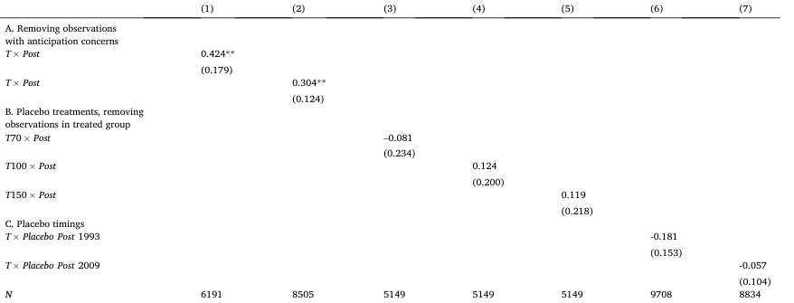

NOTE: complex table shown as an image of the PDF; the text below is a rough machine extraction and may be mis-aligned.

**extracted text (unreliable layout)**

Note: This table presents in column (1) the estimated coefficient of interest in the DiD regression without the years 2011 and 2012. In column (2), we exclude firms from treatment group with ≥50 employees between 2008 to 2010. In columns (3) to (5), we present placebo regressions for different size thresholds instead of 50 employees. We exclude from the sample firms with less than 50 employees in 2011. In column (3) the size threshold is 70; in column (4) the size threshold is 100; in column (5) the size threshold is 150. Column (6) reports the result of a placebo test in which we assume that the reform happened in 1993 instead of 2012. We then use data from 1990 to 1996, which was a period of economic slowdown and recovery at some extent similar to the one of our study, to compare treated to control number of product innovations, before (1990–1992) and after (1993–1996). Column (7) reports the result of a placebo test in which we assume that the reform happened in 2009 instead of 2012. We use data from 2007 to 2011 to compare treated to control number of product innovations, before (2007–2008) and after (2009–2011). In all regressions the dependent is the number of product innovations and we include firm and year FEs. Standard errors clustered at the firm-level are presented in pa rentheses. * *p <* 0*.*10*,* ** *p <* 0*.*05*,* *** *p <* 0*.*01

**Table 4** Pre-reform time trends.

| Dependentvariable | No. of product | Employment | Sales |
| --- | --- | --- | --- |
|  | innovations | growth | growth |
|  | (1) | (2) | (3) |
| T ×2007 | 0064 . (0129) . | -0 .011 (0011) . | 0010 . (0014) . |
| T ×2008 | 0086 . (0144) . | -0 .002 (0012) . | -0 .005 (0015) . |
| T ×2009 | 0026 . | 0005 . | 0004 . |
| T ×2010 | (0161) . -0 .047 (0188) . | (0012) . 0010 . (0011) . | (0017) . -0 .001 (0016) . |
| T ×2011 | 0051 . | -0 .007 | -0 .019 |
|  | (0195) . | (0011) . | (0015) . |
| Pre-trends F-stat | 026 . | 105 . | 093 . |
| p-value | 093 . | 038 . | 046 . |
| N | 10480 | 10480 | 10480 |

NOTE: table converted from PDF layout to HTML text; cell boundaries are reconstructed. See PDF if exact alignment matters.

Note: This table presents the results from the DiD regression for the pre-reform years (the sample is from 2006 to 2011). The dependent variable in column (1) is the number of product innovations; in column (2) is employment growth; and in column (3) is sales growth. The regression includes firm and year FEs. The F- statistic tests whether all the interaction terms between treatment indicator and time dummy variables are jointly zero. Standard errors clustered at the firm- level are presented in parentheses. * *p <* 0*.*10*,* ** *p <* 0*.*05*,* *** *p <* 0*.*01

*M. García-Vega et al.*

Page 9

*Research Policy 50 (2021) 104213*

9

expected result of no statistically significant differences between the placebo and control group after the reform for any of the arbitrarily chosen thresholds. This supports the view that our baseline results capture the effect of the EPL reform rather spurious differences in the rate of product innovation across firms of different sizes.

Finally, we perform two placebo exercises assuming that the reform happened in a different year. Even if pre-reform period the trends are parallel, as previously shown, it is possible that there is a change in the slope of innovation between treated and control group in the post- reform period for reasons that are unrelated to our labor market re form. For example, a repeated concern has been that small firms recover more quickly than large firms in a period of economic recovery, as occurred for the post-reform period, and therefore innovate more than the treated group. We test the plausibility of this hypothesis by comparing the recovery of small and large firms during other, earlier recessionary periods. In Spain, there was a recession period at the beginning of the 90s; with a decline in GDP growth from 1990 until 1993 and a recovery period from 1993 to 1996.<sup>21</sup>We assume that the reform happened in 1993 instead of 2012. We then use data from 1990 to 1996 to compare treated to control number of product innovations for the placebo pre-reform period (1990 to 1992) and the placebo post-reform period (1993 to 1996). We report the estimated coefficient from this placebo timing in column (6) of Table 5 and as expected find no sta tistically significant effect of treatment in this recessionary period. Indeed, the estimated coefficient is negative, which suggests that the treated group innovated less after this recession than the large firms of the control group. We also consider a more recent period, the global financial crisis. Here we assume that the reform happened in 2009 instead of 2012. We then use data from 2007 to 2011 to compare treated to control number of product innovations for the placebo pre-reform period (2007 and 2008) and the placebo post-reform period (2009 to 2011). We report the estimated coefficient from this placebo timing test in column (7) of Table 5 and again find no statistically significant effect of treatment in this placebo period.

*5.2.3. Further robustness checks* In Table 6, we show results of regressions where we exclude different subsamples of firms. Our main specification is based on all firms, irre spective of their initial size. This has the advantage that the sample is independent of firms past innovation success, which may have deter mined their growth—and thus size—in the pre-reform period. A disad vantage of this approach is that arguably, it makes it more likely the treatment and control group differ in terms of their pre-reform charac teristics. In the previous sections of the paper, we attempted to control for this issue by controlling for fixed firm characteristics and unobserved

heterogeneity with respect to shocks. We also obtain plausible results from placebo tests. Nevertheless, in this section, we re-run our DiD analysis keeping firms within a narrow pre-treatment size range, measured as the number of employees in 2011. We consider the following samples of firms: those with more than 30 employees (column 1); with less than 70 employees (column 2); and between 30 and 70 employees (column 3). The results documented in columns (1) to (3) are in all cases positive and statistically significant at standard levels despite the reductions in the sample size. The estimated effects even increase slightly as compared to the baseline estimates.<sup>22</sup>This result suggests that our estimated effects on the number of product innovations are unlikely to be driven by unobservable time-varying firm characteristics that are correlated with initial size.

A feature of the Spanish labor market that we have not yet taken into account is the variety of employment contracts available. The dual labor market within Spain already offered firms employment flexibility through the availability of temporary contracts. The EPL reform of in terest increased the flexibility of workers on permanent contracts, which are typically higher skilled than those on temporary contracts.

To explore if the skill level was an important feature of the effects we capture, we examine if our baseline estimates are driven by firms that largely employed employees on temporary contracts before the reform. A workforce made up of temporary workers could already be easily adjusted if the firm needs to downsize.<sup>23</sup>To asses the plausibility of this as an explanation of our results, we exclude firms with a share of tem porary workers in the total workforce of 50% or more in the year before the reform. We present the results from this estimation in column (4). The estimated effects remain statistically significant at standard levels and, in fact, the estimated magnitude increases as compared to the baseline regression. This result is consistent with the limited role that temporary workers play in our sample, where the average share of temporary workers in the total firm employment for this period is below 10%. An alternative explanation for the increase in innovation by small firms after the reform, which is unrelated to labor market flexibility, is a relaxation of credit constraints due to the financial incentives associated with the policy. As a reminder, the reform also provided an employment subsidy to the treatment firms. To investigate whether this is a likely explanation, we exploit a question from the ESEE survey, which asks

**Table 6** Robustness checks: definitions of treatment and control group.

|  | (1) | (2) | (3) | (4) | (5) | (6) |  |
| --- | --- | --- | --- | --- | --- | --- | --- |
| treatmentgroup | size>30 | all | 30<size<70 | temp.share< 0 .5 | fi no n.cons. | Δsize> − | 10 |
| controlgroup | all | size<70 | 30<size<70 | temp.share< 0 .5 | fi no n.cons. | Δsize> − | 10 |
| T ×Post | 0333** . | 0337* . | 0394* . | 0364** . | 0260** . | 0274** . |  |
|  | (0159) . | (0204) . | (0228) . | (0147) . | (0132) . | (0126) . |  |
| N | 6135 | 4986 | 1652 | 8718 | 7600 | 9387 |  |

NOTE: table converted from PDF layout to HTML text; cell boundaries are reconstructed. See PDF if exact alignment matters.

Note: The dependent variable is the number of product innovations. The standard errors are presented in parentheses and are clustered at the firm-level. In all re gressions we include firm and year FEs. In column (1), we exclude firms from treatment group with ≤30 employees in 2011; in column (2), we exclude firms from control group with ≥70 employees in 2011; in column (3), we only keep firms with 30 *<* size in 2011 *<* 70; in column (4), we exclude firms with share of temporary workers of 50% or more; in column (5), we exclude firms that reported financing constraints for innovation; in column (6), we exclude firms with decline in employees by 10 or more from 2011. * *p <* 0*.*10*,* ** *p <* 0*.*05*,* *** *p <* 0*.*01

21 Although the period 1990 to 1993 did not experience such a deeper recession as in during the global financial crisis, the GDP growth in 1993 was negative.

22 Although the effects are statistically significant at standard levels in these regressions, due to the smaller sample size, we note that the estimated co efficients are less precisely estimated. As mentioned before, due to the design of the reform, firms could only hire additional workers using the newly introduced contracts until they reached the size threshold of 50 employees. Therefore, a too narrow bandwidth around the threshold is unlikely to be informative about the effect of the reform.

23 One approach to the study of the effect of EPL reforms in a dual-labor market setting such as in Spain has been to use the pre-reform share of tem porary versus permanent workers (e.g., Dolado et al., 2016).

*M. García-Vega et al.*

Page 10

*Research Policy 50 (2021) 104213*

10

firms whether, in a given year, they have unsuccessfully searched for external financing of innovation. If the labor market reform induced innovation acts solely through a reduction in financing constraints, we would expect our findings so far to be driven purely by firms that pre viously reported these financing problems. However, the results in col umn (5) of Table 6, where we exclude firms that reported such problems (within the 5 years before the start of our main sample period), indicate that this is not the case. We find instead that the results are very similar to the baseline effect reported in Table 3. This result, together with the fact that only around 12% of innovating firms in both treatment and control group report external financing problems, suggest that a reduction of financial constraints is not the main channel by which the reform affected innovation.<sup>24</sup>

Finally, a requirement of the contract was that firms had not incurred in unfair or collective dismissals in the preceding 6 months. In Spain, the minimum threshold in the case of collective dismissals for firms with less than 100 workers is 10 employees. In order to account for this issue, we drop from our sample those treated firms with a decrease of at least 10 employees in a given year (from the year before the reform). We report the results from this estimation in column (6). The results are again consistent with previous evidence showing a positive and significant effect of the reform for the treated firms on product innovation.

*5.2.4. Local average treatment effects* The results presented so far measure ITT effects. To estimate local average treatment effects (LATE), we conduct instrumental variable (IV) regressions similar to Bjuggren (2018). In these regressions, we instru ment actual treatment status (*Tit* × *Postt*) using time invariant treatment status based on pre-reform size (*Ti,*2011 × *Postt*), i.e. the same variable used to estimate ITT effects in Table 3. The exclusion restriction for this instrument is likely to hold since, as we have discussed, the reform and the corresponding size threshold was not anticipated. Further, the

previous analysis of pre-reform parallel trends indicates that firms (and therefore the instrument *Ti,*2011 × *Postt*) were unlikely to be affected before the reform.

The results of the LATE using IV regressions are reported in Table 7. The estimated LATE parameters identify the effects on compliers, i.e. firms that have fewer than 50 employees in a specific year and can thus benefit from the reform in that year due to their initial size in 2011. Since some of the firms cross the threshold of 50 employees after the reform, LATE effects are per construction larger than ITT effects. In columns (1) and (2), we average the effect of the reform across all post- reform periods and in columns (3) to (5) we estimate interactions of treatment status (based on current employment) with year dummies for 2012–2015 to study how they vary on a year-by-year basis. The coeffi cient estimates in columns (1) and (2) vary between 0.35 and 0.30, depending on whether we only control for year fixed effects (column 1), or firm and year fixed effects (column 2). Either way this indicates that the number of new product innovations increases for those firms that remained in the treatment group in the post-reform period. The esti mated parameters consistently indicate an increase in innovation that starts one to two years after the reform (columns 3, 4 and 5). Such delays in the outcome of the innovation process to the policy reform are plausible and point to a genuine increase in innovation efforts by affected firms.

#### **6. The mechanism**

Having established the robustness of our main findings to several threats to identification, in this section, we investigate treatment effect heterogeneity. We use this to focus on industry characteristics for which labor market flexibility, specifically low adjustment costs, are likely to be of particular importance for firms’ product innovation decisions. We distinguish across two different dimensions: R&D sectoral intensity and sectoral market uncertainty.

A further benefit of these tests is that it allows us to question the plausibility of alternative mechanisms that might generate a positive effect from a labor market reform of the kind we study. One alternative mechanism from longer trial periods for employees would be that it allowed for better matching between firms and workers. As these matches are more productive it might be this that causes a rise in innovation. The benefit of these matches are unlikely to differ across industries, in particular when we explore measures of demand uncertainty.

If there is a causal relationship between EPL and innovation, we should see that the effects are concentrated in industries that have been more exposed to the reform. Particularly, we expect that firms with a high share of labor costs react more strongly to changes in EPL. For this purpose, we split our sample according to the labor share at the industry level, defined as the ratio of the wage bill to tangible investments for the pre-sample period 2000 to 2007. We present these results in columns (1) to (4) of Table 8. In columns (1) and (2), we split the sample between firms in sectors with above average labor share and below average labor share, respectively. In column (3) and (4), we show results when we distinguish between sectors with labor share above and below the 75th percentile of the labor share distribution, respectively. Our results sug gest that the effect of the reform is indeed concentrated in industries with high labor share which confirms our hypothesis 2.

As argued by Bartelsman et al. (2016) and Akcigit and Kerr (2018), innovations are often characterized as having higher expected, but more uncertain, returns. This uncertainty is likely to increase in R&D intensive sectors due to the importance of innovations and rapid rate of techno logical change. Moreover, R&D intensive sectors are typically very dy namic and in need to introduce aggressively new products and scale up (or down) quickly in order to take advantage of economies of scale (Dosi, 1982; Jansen et al., 2006; Pavitt, 1984, among others). We thus expect the reform to have larger effects on innovation incentives in these in dustries. For this analysis, we stratify the sample by distinguishing

**Table 7** Local average treatment effects (LATE) for product innovations from IV regressions.

[output not shown]

NOTE: table converted from PDF layout to HTML text; cell boundaries are reconstructed. See PDF if exact alignment matters.

Note: The dependent variable is the number of product innovations. The stan dard errors are presented in parentheses and are clustered at the firm-level. In columns (1) and (3), we control for time invariant treatment status and year FE; in columns (2) and (4), we control for firm and year FE; in column (5) we control for firm FE, industry-year and region-year FE. * *p <* 0*.*10*,* ** *p <* 0*.*05*,* *** *p <* 0*.*01

24 Consistent with the limited role of the employment subsidy in our sample, Gamberoni et al. (2016) show that there is little evidence that this subsidy induced employment growth.

between firms that operate in sectors with R&D intensity (defined as total R&D expenditures over sales) above the median and below the median. Our sectoral measure of R&D intensity is the average firm-level R&D intensity in a sector in the pre-sample years (from 2000 to 2009).<sup>25</sup>

We show results from this sample split in columns (1) and (2) of Table 9, where we distinguish between R&D intensive sectors in column (1) and non-R&D intensive sectors in column (2). The results indicate that the effects of the labor market reform are clearly concentrated in industries with R&D intensity above the median. The estimated effect of the EPL changes for these groups of firms are larger than those in the baseline estimates in Table 3. For firms in non-R&D intensive industries, the estimated coefficients are substantially smaller and statistically insignificant. Moreover, the standard errors in these regressions are of a similar size to those reported previously, suggesting that these near zero effects are well identified. We also report the p-value for the hypotheses that the effects are equal between high and low R&D intensive industries and we can reject at conventional statistical levels that the effects are the same between industries.

A drawback of the above stratification is that industry-level R&D intensity is an outcome of the activities of firms in our sample. As an alternative, we therefore use the well-known taxonomy by Pavitt (1984) which classifies industries into science-based, specialized suppliers, scale and information and supplier dominated industries. Results depicted in columns (3) to (6) of Table 9 show that the overall effects of the reform are driven by science-based industries which are typically characterized by the highest levels of R&D intensity and uncertainty.

Along with firms that operate in R&D intensive industries, we also expect that new product innovations are affected more in industries characterized by greater market uncertainty. In industries where un certainty is high, the reform might have had a greater impact on in centives to innovate since unforeseen events, that require adjustment of the labor force, occur with higher frequency. To investigate the role of uncertainty, we stratify the data in two different ways: First, in the survey, the firms report whether there have been important changes in their main market due to changes in the demand, in their competitors prices or in the products of their competitors. With this information, we construct a dummy variable that takes the value one if a firm reports a change in the demand of their main market in a given year. Then, we calculate the average sectoral value of the demand changes for the pre-

sample period and we stratify the sample between sectors above the median and below the median. We report the results from this sample split in columns (1) and (2) in Table 10, and the p-value for the equality between sectors at the bottom of the table. The results indicate that the effects are concentrated in sectors with high demand changes. We can again reject at conventional levels that the effects are the same between sectors.

Second, we follow Czarnitzki and Toole, 2011 and compute a mea sure of product market uncertainty at the firm-level as follows:

**equation / math rendering (image)**

NOTE: contains mathematical notation; text above is the PDF text layer and symbols may be mis-extracted. Image shows the original.

**equation / math rendering (image)**

NOTE: contains mathematical notation; text above is the PDF text layer and symbols may be mis-extracted. Image shows the original.

**equation / math rendering (image)**

NOTE: contains mathematical notation; text above is the PDF text layer and symbols may be mis-extracted. Image shows the original.

**equation / math rendering (image)**

NOTE: contains mathematical notation; text above is the PDF text layer and symbols may be mis-extracted. Image shows the original.

**equation / math rendering (image)**

NOTE: contains mathematical notation; text above is the PDF text layer and symbols may be mis-extracted. Image shows the original.

**equation / math rendering (image)**

NOTE: contains mathematical notation; text above is the PDF text layer and symbols may be mis-extracted. Image shows the original.

**equation / math rendering (image)**

NOTE: contains mathematical notation; text above is the PDF text layer and symbols may be mis-extracted. Image shows the original.

**equation / math rendering (image)**

NOTE: contains mathematical notation; text above is the PDF text layer and symbols may be mis-extracted. Image shows the original.

where *Sit* denotes sales per employee. This uncertainty measure is based on the standard deviation of sales per employee and thus measures the variability of sales per worker across years. We divide the standard deviation by the average level of sales per employee to obtain a measure that is comparable across firms of different size. Our industry-level measure of uncertainty is simply the average of the firm-level measure across all firms in an industry. To reduce endogeneity problems, we

**Table 9** Heterogeneous effects: Industry heterogeneity by R&D intensity, and Pavitt’s taxonomy sector classification.

| Industries | R&Dintensity |  | Pavitt’staxonomy |  |  |  |
| --- | --- | --- | --- | --- | --- | --- |
|  | High | Low | Science | Specialized | Scaleand | Supplier |
|  |  |  | based | suppliers | information | dominated |
|  | (1) | (2) | (3) | (4) | (5) | (6) |
| T ×Post | 0502*** . | 0017 . | 0920** . | –0 .053 | 0111 . | 0192 . |
|  | (0181) . | (0155) . | (0427) . | (0205) . | (0181) . | (0192) . |
| N | 4715 | 4754 | 1570 | 1154 | 2683 | 3086 |
| p-value |  |  |  |  |  |  |
| equalcoeffi cients | 0043 . |  |  |  |  |  |

NOTE: table converted from PDF layout to HTML text; cell boundaries are reconstructed. See PDF if exact alignment matters.

Note: The dependent variable is the number of product innovations. The standard errors are presented in parentheses and are clustered at the firm-level. We stratify the sample as follows: In column (1), we run separate regressions for firms with R&D intensity above the median based on the pre-sample period; in column (2), for firms with R&D intensity below the median based on the pre-sample period; in columns (3) to (6) we distinguish by Pavitt’s sectoral taxonomy: in column (3) for firms in *science-based* sectors; in column (4), for firms in *specialized suppliers* sectors; in column (5), for firms in *scale and information intensive* sectors; in column (6), for firms in *supplier dominated* sectors. In all regressions, we control for firm and year FE. For columns (1) and (2), we also report the p-value corresponding to the null hypothesis that the effects are the same in both subsamples. * *p <* 0*.*10*,* ** *p <* 0*.*05*,* *** *p <* 0*.*01

**Table 8** Heterogeneous effects: Industry heterogeneity by labor share.

| Industries | Above&belowmedian Above Below | Above&below Above | 75% Below |
| --- | --- | --- | --- |
|  | (1) (2) | (3) | (4) |
| T ×Post | 0424* 0148 . . | 0888*** . | 0046 . |
|  | (0219) (0140) . . | (0280) . | (0140) . |
| N | 4806 4663 | 2801 | 6668 |
| p eq-v ua al lu ce o e f f i cients | 0282 . | 0008 . |  |

NOTE: table converted from PDF layout to HTML text; cell boundaries are reconstructed. See PDF if exact alignment matters.

Note: The dependent variable is the number of product innovations. The stan dard errors are presented in parentheses and are clustered at the firm-level. We stratify the sample as follows: In column (1), we run separate regressions for firms in sectors with labor share above the median based on pre-sample years; in column (2), for firms in sectors with labor share below the median based on pre- sample years; in column (3), for firms in sectors with labor share above the 75% of the labor share distribution based on pre-sample years; in column (4), for firms in industries with labor share below the 75% labor share distribution based on pre-sample years. In all regressions, we control for firm and year FE. We also report the p-value corresponding to the null hypothesis that the effects are the same in both subsamples. * *p <* 0*.*10*,* ** *p <* 0*.*05*,* *** *p <* 0*.*01

25 Our results are robust to alternative time periods for the calculation of R&D intensity, such as not including the global financial crisis years, that is considering the period from 2000 to 2007, or considering just the year before the reform, that is the year 2011.

compute the uncertainty measure over pre-sample years only.<sup>26</sup>We report the results in columns (3) and (4) in Table 10 and the p-value of a test for equality of coefficients across subsamples at the bottom of the table. The results suggest that the effects on innovation are most pro nounced in industries with high volatility, indicating that the reform, at least partially, induced innovation due to a reduction in adjustment costs. Overall, the results from the different data stratifications suggest that the reform encouraged firms to innovate by offering greater flexi bility to scale up or down quickly in the event of successful, or unsuc cessful innovation. Our results are thus consistent with hypothesis 3.

As an alternative measure of industry-level volatility, we follow (Bozkaya and Kerr, 2014) and construct a measure of labor volatility, defined as the maximum of the absolute value of employment growth across firms within industries over the pre-sample period 2000–2007. As EPL is likely to be binding only when employment volatility is signifi cant, we expect larger effects of the reform in industries where volatility is relatively high. Results in columns (5) and (6) of Table 10 confirm that the conclusions are very similar to those regressions where we use sales

volatility as a sample split.

#### **7. Further outcome variables**

The previous sections show a robust effect of the labor market reform on the number of product innovations, which is the innovation output measure that is the most directly related to the presumed mechanism of adjustment costs. We use this section of the paper to consider other firm- level outcomes that might be expected to change alongside product innovation.

In Panel A of Table 11, we show results using alternative innovation indicators including whether the firm has introduced new methods for organizing the work or organizational labor innovations (column 1), change in the number of markets where the firm operates (column 2), a dummy variable for imports of technology (column 3), its value in logs (column 4) and the number of patents (column 5).<sup>27</sup>All in all, the results suggest the reform led affected firms to undertake a range of other

**Table 11** Alternative innovation indicators.

| Dependentvariable | Organizational | Δnumber | Havingimports | Importsof | Patents |
| --- | --- | --- | --- | --- | --- |
|  | laborinnovation | ofmarkets | oftechnology | technology(Ln) |  |
|  | (1) | (2) | (3) | (4) | (5) |
| PanelA |  |  |  |  |  |
| T ×Post | 0021 . | 0041 . | 0035*** . | 1422** . | 0017** . |
| PanelB | (0016) . | (0025) . | (0008) . | (0655) . | (0008) . |
| T ×2011 | –0 .012 | 0049 . | 0006 . | -0 .495 | 0013 . |
|  | (0019) . | (0045) . | (0005) . | (0505) . | (0013) . |
| T ×2012 | 0059*** . | 0024 . | 0099*** . | 2303*** . | 0026** . |
|  | (0022) . | (0040) . | (0012) . | (0640) . | (0013) . |
| T ×2013 | –0 .015 | 0113*** . | 0013 . | -0 .079 | 0018 . |
|  | (0024) . | (0039) . | (0009) . | (423) . | (0014) . |
| T ×2014 | 0008 . | 0083** . | 0016 . | 0103 . | 0024* . |
|  | (0025) . | (0039) . | (0010) . | (0461) . | (0014) . |
| T ×2015 | –0 .006 | 0056 . | 0003 . | 0233 . | 0027* . |
|  | (0026) . | (0040) . | (0010) . | (0388) . | (0015) . |
| N | 9469 | 9469 | 9456 | 1961 | 9465 |

NOTE: table converted from PDF layout to HTML text; cell boundaries are reconstructed. See PDF if exact alignment matters.

Note: The dependent variable in column (1) is an indicator that takes the value one if the firm undertakes organizational labor innovations, in column (2) is the change in the number of markets; in columns (3) is an indicator that takes the value one if the firm undertakes imports technology; in column (4) is the natural logarithm of the imports of technology and in column (5) is the growth of the patent stock. The standard errors are presented in parentheses and are clustered at the firm-level. In all regressions, we control for firm and year FE. * *p <* 0*.*10*,* ** *p <* 0*.*05*,* *** *p <* 0*.*01

**Table 10** Heterogeneous effects: Industry heterogeneity by labor volatility, changes in the demand of the main market and sales volatility.

| Industries | Demandchanges |  | Salesvolatility |  |  | Laborvolatility |  |
| --- | --- | --- | --- | --- | --- | --- | --- |
|  | High | Low | High |  | Low | High | Low |
|  | (1) | (2) | (3) |  | (4) | (5) | (6) |
| T ×Post | 0519*** . | –0 .006 | 0503*** . |  | –0 .047 | 0537*** . | -0 .129 |
|  | (0155) . | (0200) . | (0152) . |  | (0215) . | (0157) . | (0216) . |
| N | 4876 | 4593 | 5457 |  | 4012 | 5817 | 3652 |
| p-value |  |  |  |  |  |  |  |
| equalcoeffi cients | 0041 . |  |  | 0038 . |  | 0017 . |  |

NOTE: table converted from PDF layout to HTML text; cell boundaries are reconstructed. See PDF if exact alignment matters.

Note: The dependent variable is the number of product innovations. The standard errors are presented in parentheses and are clustered at the firm-level. We stratify the sample as follows: In column (1), we run separate regressions for firms with: in column (1), for firms with changes in the demand of their main market above the media based on pre-sample years; in column (2), for firms with changes in the demand of their main market below the median based on pre-sample years; in column (3), for firms in industries with volatility above the median based on all pre-sample years; in column (4), for firms in industries with volatility below the median based on all pre-sample years; in column (5), for labor volatility above the median based on pre-sample years; in column (6), for firms with labor volatility below the median based on pre-sample years. In all regressions, we control for firm and year FE. We also report the p-value corresponding to the null hypothesis that the effects are the same in both subsamples. * *p <* 0*.*10*,* ** *p <* 0*.*05*,* *** *p <* 0*.*01

26 Our results are also robust to different time periods such as all years from 1990 until 2007, or using the years 2003 to 2007 only.

27 Since arguably not all innovations are patented and specifically the number of patents granted to small firms is rather small, we prefer to focus on the number of product innovations as our main outcome variable.

actions that are consistent with an increase in product innovation. We find a strong statistically significant effect on imports of technology in columns (3) and (4) and on patents in column (5). For columns (1) and (2), the estimated coefficients are positive but they are not statistically significant at standard levels. We investigate this point further in Panel B of Table 11, where we repeat the analysis from Panel A, and interact treatment status with year dummies. As before, treatment status is based on employment in 2011. The results in Panel B show that the insignifi cant outcome in Panel A can largely be explained by treatment effects that are concentrated in certain post-reform years. The results indicate

that all of the innovation-related outcomes increase significantly in at least one of the post-reform periods but the timing differs across the various measures.

Our results for the innovation related variables indicate that the labor market reform induced investment by enabling firms to better adjust to uncertain events. Innovation is often associated with new market entry. Since export market entry can be interpreted as an in vestment with high sunk costs and uncertain returns, a hypothesis consistent with our previous results is that firms in the treatment group are more likely to start exporting after the reform (Lileeva and Trefler, 2010). Within the model of Lileeva and Trefler (2010) exports and innovation are jointly determined and therefore both would be expected to be positively affected by the labor market reform.

In Table 12, we explore the effect of the labor market reform on the incidence of exporting. Results in column (1), where we pool over all post-reform years, are positive but only weakly significant. However, as shown in column (2), where we distinguish across years, this is mainly due to time-heterogeneous treatment effects. In columns (3) and (4), we investigate treatment effect heterogeneity by industry-level uncertainty. In contrast to the sample split for product innovations, we use export sales instead of total sales to measure sales per employee, which should be more relevant for export decisions. The results indicate that the re form induced exporting in high-volatility industries but not in low- volatility industries, consistent with our results for product innova tion. This result is in line with Cu˜nat and Melitz (2012), who find that countries with higher labor market flexibility export relatively more in high-volatility industries.

Further, we analyse additional outcome variables such as sales rev enue growth, growth in the physical quantity sold, growth in the prices of final goods, and growth in the price of materials, physical total factor productivity (TFP) and labor volatility. The construction of the different variables that we use for this part of our analysis is as follows: The variable sales growth is measured in yearly log changes. The growth of the physical quantity index is obtained by deflating sales using a firm- specific output price deflator. The companies report information about specific price indices of outputs and material inputs, which we consider in logarithms. TFP is measured as the residual from a production func tion. To estimate the production function, we relate sales to materials, labor input (measured by hours worked), and the capital

**Table 13** Effects on sales, quantities, prices, TFP, labor volatility and complementary investments

| Dependentvariable | Sales | Quantity | Price | Materialprice | TFP | Laborvolatility | Training | HumanK | R&D plan. | Subs. cred . |
| --- | --- | --- | --- | --- | --- | --- | --- | --- | --- | --- |
|  | (1) | (2) | (3) | (4) | (5) | (6) | (7) | (8) | (9) | 10 |
| PanelA |  |  |  |  |  |  |  |  |  |  |
| T ×Post | 0036*** . | 0027*** . | 0009*** . | 0011*** . | 0009 . | 0017** . | 0018* . | 0100*** . | 0037*** . | 0023*** . |
| PanelB | (0010) . | (0010) . | (0003) . | (0003) . | (0009) . | (0008) . | (0019) . | (0043) . | (0015) . | (0012) . |
| T ×2011 | –0 .016 | –0 .016 | –0 .001 | 0002 . | -0 .017 |  | 0017 . |  | 0002 . | 0005 . |
|  | (0016) . | (0016) . | (0003) . | (0004) . | (0021) . |  | (0012) . |  | (0015) . | (0012) . |
| T ×2012 | 0013 . | 0005 . | 0008** . | 0010** . | 0003 . |  | 0012 . |  | 0027 . | 0014 . |
|  | (0016) . | (0016) . | (0004) . | (0005) . | (0014) . |  | (0015) . |  | (0019) . | (0015) . |
| T ×2013 | 0021 . | 0013 . | 0007** . | 0013*** . | -0 .002 |  | 0031** . |  | 0045** . | 0022 . |
|  | (0016) . | (0016) . | (0004) . | (0005) . | (0014) . |  | (0014) . |  | (0021) . | (0015) . |
| T ×2014 | 0046*** . | 0037** . | 0010*** . | 0014*** . | -0 .000 |  | 0048*** . | 0100*** . | 0038 . | 0032** . |
|  | (0017) . | (0017) . | (0004) . | (0005) . | (0013) . |  | (0017) . | (0043) . | (0023) . | (0016) . |
| T ×2015 | 0038** . | 0029* . | 0009*** . | 0013*** . | -0 .000 |  | 0020 . |  | 0046** . | 0038** . |
|  | (0017) . | (0017) . | (0004) . | (0005) . | (0013) . |  | (0015) . |  | (0024) . | (0016) . |
| N | 8352 | 8352 | 8352 | 8352 | 8352 | 2949 | 8346 | 809 | 9469 | 9469 |

NOTE: table converted from PDF layout to HTML text; cell boundaries are reconstructed. See PDF if exact alignment matters.

Note: The dependent variable in column (1) is sales growth; in column (2) is quantity growth calculated as an index of physical output using a firm-specific output price deflator; in column (3) is the growth of a firm-specific output price index; in column (4) is the growth of a firm-specific material price index; in column (5) is the growth in physical TFP calculated using the ACF algorithm and firm-specific deflators; in column (6) is the standard deviation of the growth of the employment for the pre and post-reform period (and consequently with only two observations); in column (7) is the ratio of the log of employees’ training in information and technology per employee; in column (8) is the ratio of high-skilled workers in R&D (those with the highest academic qualification) over total workers in R&D. Note that there is only information of this variable for the years 2010 and 2014; in column (9) is a dummy variable indicating investment in R&D planning; in column (10) is a dummy variable indicating a subsidized credit for innovation activity. The standard errors are presented in parentheses and are clustered at the firm-level. In all regressions, we control for firm and year FE. * *p <* 0*.*10*,* ** *p <* 0*.*05*,* *** *p <* 0*.*01

**Table 12** Effects on Exports.

| Industries | All | All | Exportsalesvolatility |  |
| --- | --- | --- | --- | --- |
|  | (1) | (2) | High (3) | Low (4) |
| T ×Post | 0015* . |  | 0028** . | -0 .007 |
| T ×2011 T ×2012 T ×2013 T ×2014 | (0009) . | 0006 . (0017) . 0025* . (0015) . 0000 . (0016) . 0032** . | (0013) . | (0013) . |
| T ×2015 |  | (0016) . 0013 . |  |  |
|  |  | (0015) . |  |  |
| N | 9469 | 9469 | 5020 | 4449 |
| p-value |  |  |  |  |
| equalcoeffi cients |  |  |  | 0042 . |

NOTE: table converted from PDF layout to HTML text; cell boundaries are reconstructed. See PDF if exact alignment matters.

Note: The dependent variable is the change in export status. In columns (1) and (2) we include the full sample. In columns (3) and (4), we stratify the sample as follows: In column (3), we include industries with export sales volatility above the median. In column (4), we include industries with export sales volatility below the median. The standard errors are presented in parentheses and are clustered at the firm-level. In all regressions, we control for firm and year FE. We also report the p-value corresponding to the null hypothesis that the effects are the same in both subsamples of columns (3) and (4). * *p <* 0*.*10*,* ** *p <* 0*.*05*,* *** *p <* 0*.*01

stock—constructed from fixed assets. To account for pricing heteroge neity across firms and industries, we deflate sales using firm-specific price deflator to obtain a measure of physical output. Further, mate rials are deflated using a firm-specific input price index and capital is deflated using industry-level capital prices from EU Klems. Production functions are estimated separately by 2-digit industry using the method suggested by Ackerberg et al. (2015). We also account for measurement error in capital following Collard-Wexler and De Loecker (2016). Employment volatility is the standard deviation of the growth of the employment for the pre and post-reform period.<sup>28</sup>

The results are presented in Table 13, where we show the average ef fect in Panel A, and we present time-heterogeneous effects in Panel B. The results in both panels indicate that the reform induced sales revenue growth (column 1), as would be expected if the firm adds to its portfolio of products. As can be seen in columns 2 and 3 respectively, the rise in sales growth is mainly due to higher quantities sold and to a lesser extent due to higher prices charged. The result of higher quantities besides higher prices is consistent with quality upgrading. This is also in line with the rise of material prices, shown in column 4, under the common assumption that high quality outputs require inputs of high quality, which is reflected in input prices (Kugler and Verhoogen, 2011). We present results on TFP in column 5. The fact that physical TFP is not significantly affected indicates that investment induced by the reform has been directed towards intro ducing new products and improving existing products rather than reducing production costs. Moreover, after the reform firms seem to in crease their employment volatility (column 6). The overall conclusion from these estimations is that after the reform, the treated firms increase their sales and that average product quality has increased and their employment become more flexible. These results support again the idea of an increase in firm innovation occurred amongst treated firms due to a reduction in labor adjustment costs.

Finally, to innovate, firms may need sufficient human and physical capital. For this purpose, we analyse whether firms were undertaking complementary investments to upgrade human capital as a response to the reform. In column (7), we present results for investment in training for information and communication technologies per employee (measured in logs) which show that these expenditures indeed increase around the time of the reform. In column (8), we study the effect on human capital working in R&D, which we measure as the ratio of R&D employees with the highest academic qualification over the total num ber of employees in R&D.<sup>29</sup>The results suggest that the reform increased R&D human capital. We also analyse whether firms undertake invest ment in R&D planning and obtain subsidized credit for innovation which we both measure as dummy variables. Results depicted in columns (9) and (10) of Table 13 show that these variables are also positively affected by the reform, consistent with a real change in innovation ac tions amongst treated firms in the years following the policy reform.

#### **8. Magnitude of the effect, discussion and policy implications**

To provide a summary of the magnitude of the effect of the reform on innovation in the economy, we construct an innovation index (for example as in Bloom et al., 2016), which weights the estimated increase in innovation that is caused by the reform by the share of affected firms’

*Si* from data in the pre-reform year. From Table 3, we obtain the estimated change in product innovation stock (*Ii*1 −*Ii*0) which ranges from 0.263 to 0.3. This implies that the average innovation stock across all firms in our sample (including non-treated firms) increases between 0.054 and 0.063. Based on the average pre-reform innovation stock of 1.53, this implies an increase in overall innovation of 3.5% to 4%.<sup>30</sup>

The policy studied within this paper has very specific characteristics; it provided extended trial periods for workers offered permanent con tract by small firms. These characteristics may in turn help to explain the strong effects that we find. Workers on permanent contracts are typically higher skilled than those on temporary contracts, where temporary contracts already offer flexibility in employing the marginal worker within Spain. This is consistent with the idea that adjustment costs amongst higher skilled workers fell as a consequence of the policy change. Our results also show that these effects are concentrated amongst small firms in R&D intensive industries, in industries charac terised by demand uncertainty and in industries where the labor share of income is high. Moreover, our results suggest that the reform incentiv ized investments in skills and led to increased domestic sales as well as exports. We also note that the type of innovation conducted by small and young firms is often different from that for large firms. Small firms tend to invest in more radical innovations than large firms, which, on average tend to focus on incremental innovations (Akcigit and Kerr, 2018).

From this, we might conclude for policy that calculations of the costs and benefits of EPL should include their effects on innovation through this channel. Given that adjustment costs (Saint-Paul, 1997; Samaniego, 2006) and skill (Leiponen, 2005) have been found to be determinants of innovation, both for product and process innovations, and radical and incremental innovations, we might also infer that policy changes which affect adjustment costs for higher skilled workers are also likely to improve the rate of innovation in other country settings.

When considering the broader policy implications of this policy, we note firstly that we capture the short-run partial equilibrium effects.<sup>31</sup>

Unfortunately, data limitations due to the length period of the survey, mean that we cannot study whether the increased short-run incentive to innovate persists over the longer-run amongst affected firms. We draw on the existing literature to highlight two possibilities for the long-term effect of the reform. One possibility is that the reform has a positive long- term effect due to the evidence of persistence in the innovation process. For example, Holbrook et al. (2000) show that past innovation experi ence is a key determinant of future innovation. An alternative possibility is that the reform has a negative long-term effect. The main reason is that firms are incentivised to remain below the threshold of 50 em ployees over the long run to take advantage of the policy. As shown as long ago as Galbraith (1952), size and age are positively correlated with innovation.<sup>32</sup>Here we note that (Aghion et al., 2021) find evidence that such sized-based labor market restrictions can reduce innovation in centives, although they do find that such firms are more likely to un dertake radical innovations to grow well beyond the threshold in such circumstances. That we find the effects of the reform are concentrated in industries where innovation is likely, it would seem plausible that such effects would occur as a consequence of the policy change studied here.

28 For a recent reference see for example (Borowczyk-Martins and Lal´e, 2019). 29 Note that, for this variable, we only have information for the years 2010 and 2014.

30 In this calculation, we abstract from heterogeneous effects of the reform across firms with different innovation shares. We also implicitly assume that the effects of the reform on innovation shares are negligible. Alternatively, we can allow shares to be affected by the reform and approximate this by pre and post- reform observed innovation shares such that: Δ*P* = <sup>∑</sup>*<sup>N</sup><sup>T</sup>*

**equation / math rendering (image)**

NOTE: contains mathematical notation; text above is the PDF text layer and symbols may be mis-extracted. Image shows the original.

**equation / math rendering (image)**

NOTE: contains mathematical notation; text above is the PDF text layer and symbols may be mis-extracted. Image shows the original.

31 During this time period, the average salary for high-skilled workers was stable. This suggests that there might not have been an aggregate resource constraint that could affect aggregate employment.

32 See Cohen (2010) for a review.

As a second point, we note that we do not study the general equi librium effects of the policy change. A range of additional effects might be included amongst these. Within firms, Lagos (2006) argues that if less stringent EPL lowers reservation wages, average productivity can fall because firms become less selective and more productive matches be tween firms and workers are not realised. Alternatively, working in the opposite direction, Bertola (1994) constructs a growth model where lower job security increases returns to investment and capital accumu lation. This would then raise growth rates and might be viewed as consistent with the evidence we find.

There may be additional effects due to structural change. Rogerson (2008) for example, albeit with respect to distortions to incentives for capital investment from EPL, finds that that structural change within the economy may slow down. Using a general equilibrium framework, Hopenhayn and Rogerson (1993) show how reduced firing restrictions can reduce distortions and push firms to use resources more efficiently. As a result, employment levels adjust more quickly and productivity is increased. Finally, Samaniego (2006) also emphasises industry composition. In a vintage capital model he shows that firms optimally reduce their workforce as they fall behind the technological frontier. As a consequence, reduced restrictions benefit in dustries characterised by rapid technological change, in a way similar to what we find. This could help shift countries towards industries where the rate of technical change is faster.

#### **9. Summary and concluding remarks**

In this paper, we study the effects of a reduction of EPL on innova tion. This is important for understanding the links between labor market regulations and long-term economic growth. We study the effect of a labor market reform that provided additional flexibility to firms with fewer than 50 employees. The reform enabled firms to hire workers on a permanent basis for an extended trial period, thereby decreasing the effective firing costs for these firms.

The labor reform took place in Spain in the year 2012 and our analysis uses data of a representative sample of Spanish manufacturing firms for the period 2010 to 2015. We explore the natural experiment in a difference-in-differences framework and find that the reform increased product innovations, product quality, enabled firms to enter new mar kets (including export markets) and to grow sales faster. We show that these effects are concentrated among firms that operate in industries with high R&D intensity and high demand volatility.

Taking together, our empirical results support theories which predict that a decrease in EPL through a decline in firing costs can reduce adjust ment costs of employment to changes in demand, increasing the incentives to invest in innovation (Saint-Paul, 1997). More generally, our study also supports theoretical arguments that consider that a more-flexible labor market might lead to aggregate growth through firm investment in risky innovations (Bartelsman et al., 2016; Mukoyama and Osotimehin, 2019; Saint-Paul, 1997; Samaniego, 2006) and to induce comparative advantage in more volatile innovative sectors (Cu˜nat and Melitz, 2012).

Our results indicate that changes in EPL for small firms can have important consequences for firm innovation patters in times of economic uncertainty. However, these effects are largely concentrated in firms that operate in environments that require high flexibility. Moreover, the innovative behaviour of large firms might be different to that of small firms when they face a reduction in adjustment costs. As it is well-known since (Williamson, 1985) (chapter 6), large firms might be less creative and innovative than small firms due to their high organizational bu reaucracy, the routinization of their R&D investments (Baumol, 2002), and their focus on exploitation R&D (Akcigit and Kerr, 2018).

This paper also contributes to the understanding of the effects of EPL at a broader level. Our findings highlight the importance of labor market reforms to contribute to firm innovation, but also the quality of new products and firm growth. Overall, our findings suggest that when policy

makers are looking for policies to promote innovation and local growth, they should also consider labor reforms that aim to reduce adjustment costs of firms operating in environments where demand uncertainty is high.

#### **CRediT authorship contribution statement**

**María García-Vega:** Methodology, Software, Conceptualization, Formal analysis, Writing - original draft, Writing - review & editing. **Richard Kneller:** Supervision, Methodology, Conceptualization, Writing - original draft, Writing - review & editing. **Joel Stiebale:** Methodology, Software, Conceptualization, Formal analysis, Writing - original draft, Writing - review & editing.

#### **Declaration of Competing Interest**

The authors declare that they have no known competing financial interests or personal relationships that could have appeared to influence the work reported in this paper.

#### **Acknowledgment**

This research has been partially funded by the Leibniz Foundation. We would like to thank Andr´es Barge-Gil, Abigail Barr, Samuel Bento lila, Sebastian Braun, Juan Jos´e Dolado, Florentino Felgueroso, Marcel Jansen, Jordi Jaumandreu, Andreas Lichter, Juan Ma˜nez, Carlos Serrano, the editor Adam Jaffe and three anonymous referees for their very helpful comments along with seminar participants at the IV KISS Workshop (Valencia), 8th ZEW MaCCI Conference on the Economics of Innovation and Patenting (Mannheim), EARIE Conference (Barcelona) and the Pakt Workshop (Essen).

#### **Appendix**

**Table A1** Sectoral distribution of firms in 2010.

[output not shown]

NOTE: table converted from PDF layout to HTML text; cell boundaries are reconstructed. See PDF if exact alignment matters.

Sectoral affiliation is based on the year 2010. We use the same aggregation of sectoral classification as Doraszelski and Jaumandreu (2013, 2018), who use the same data source. The industry definitions are as follows: Metals and metals products correspond to categories 12 & 13 from EESE and C24 & 25 from ISIC (Rev.4); Agricultural and industrial machinery includes sectr 14 from EESE and C28 from ISIC (Rev. 4); Office machinery, IT machinery, optics, electrical ma chinery includes sectors 15 & 16 from EESE and C26 & C27 from ISIC (Rev. 4) Non-metallic minerals includes category 11 from EESE and C23 from ISIC (Rev.4); Chemical products includes sectors 9 & 10 from EESE and C20 to C22 from ISIC (Rev. 4) Transport equipment includes sectors 17 & 18 from EESE and C29 & C30 from ISIC (Rev. 4); Food, drink and tobacco includes sectors 1 to 3 from EESE and C10 to C12 from ISIC (Rev. 4)l Textile, leather and shoes includes sectors 4 and 5 from EESE and C13 to C15 from ISIC (Rev. 4) Timber and furniture includes sectors 6 & 19 from EESE and C16 & C31 from ISIC (Rev. 4); Paper and printing products includes sectors 7 & 8 from EESE and C17 & C18 from ISIC (Rev. 4)

#### **References**

Acharya, V.V., Baghai, R.P., Subramanian, K.V., 2013. Labor laws and innovation. The

Journal of Law and Economics 56 (4), 997–1037. Acharya, V.V., Baghai, R.P., Subramanian, K.V., 2014. Wrongful discharge laws and

innovation. Review of Financial Studies 27 (1), 301–346. Ackerberg, D.A., Caves, K., Frazer, G., 2015. Identification properties of recent

production function estimators. Econometrica 83 (6), 2411–2451. Aghion, P., Howitt, P., 1992. A model of growth through creative destruction.

Econometrica 110, 325–351. Aghion, P., Bergeaud, A., Van Reenen, J., 2021. The impact of regulation on innovation.

In: Discussion Paper serie IZA No. 14082. Akcigit, U., Kerr, W., 2018. Growth through heterogeneous innovations. Journal of

Political Economy 126 (4), 1374–1443. Amoroso, S., Moncada-Patern`o-Castello, P., Vezzani, A., 2017. R&d profitability: the role

of risk and Knightian uncertainty. Small Business Economics 48 (2), 331–343. Angrist, J.D., Pischke, J.-S., 2008. Mostly harmless econometrics: An empiricist’s

companion. Princeton university press. Autor, D.H., Kerr, W.R., Kugler, A.D., 2007. Does employment protection reduce

productivity? evidence from us states. The Economic Journal 117 (521), F189–F217. Barbosa, N., Faria, A.P., 2011. Innovation across Europe: how important are institutional

differences? Res Policy 40 (9), 1157–1169. Bartelsman, E.J., Gautier, P.A., De Wind, J., 2016. Employment protection, technology

choice, and worker allocation. Int Econ Rev (Philadelphia) 57 (3), 787–826. Bassanini, A., Ernst, E., 2002. Labour market institutions, product market regulation, and

innovation: cross-country evidence. OECD working paper No 316. OECD. Bassanini, A., Nunziata, L., Venn, D., 2009. Job protection legislation and productivity

growth in oecd countries. Economic policy 24 (58), 349–402. Baumol, W.J., 2002. Entrepreneurship, innovation and growth: the David-Goliath

symbiosis. Journal of Entrepreneurial Finance, JEF 7 (2), 1–10. Belot, M., Boone, J., van Ours, J., 2007. Welfare effects of employment protection.

Economica 74, 381–396. Bentolila, S., Cahuc, P., Dolado, J.J., Le Barbanchon, T., 2012. Two-tier labour markets in

the great recession: France versus spain. The Economic Journal 122, F155–F187. Bertola, G., 1994. Flexibility, investment, and growth. J Monet Econ 34 (2), 215–238.

https://doi.org/10.1016/0304-3932(94)90050-7. Bertrand, M., Duflo, E., Mullainathan, S., 2004. How much should we trust differences-

in-differences estimates? Quarterly Journal of Economics 119 (1), 249–275. Bjuggren, C.M., 2018. Employment protection and labor productivity. J Public Econ 157,

138–157. Bloom, N., Draca, M., Van Reenen, J., 2016. Trade induced technical change? the impact

of Chinese imports on innovation, it and productivity. Review of Economic Studies 83 (1), 87–117. Bloom, N., Van Reenen, J., Williams, H., 2019. A toolkit of policies to promote

innovation. Journal of Economic Perspectives 33 (3), 163–184.

Boeri, T., Cahuc, P., Zylberberg, A., 2015. The costs of flexibility-enhancing structural

reforms: a literature review. OECD Economic Department Working Papers (1264). Boeri, T., Garibaldi, P., Moen, E.R., 2017. Inside severance pay. J Public Econ 145,

211–225. Bøler, E.A., Moxnes, A., Ulltveit-Moe, K.H., 2015. R&D, international sourcing, and the

joint impact on firm performance. American Economic Review 105 (12), 3704–3739. Borowczyk-Martins, D., Lal´e, E., 2019. Employment adjustment and part-time work:

lessons from the United States and the United Kingdom. American Economic Journal: Macroeconomics 11 (1), 389–435. Bozkaya, A., Kerr, W.R., 2014. Labor regulations and european venture capital. Journal

of Economics & Management Strategy 23 (4), 776–810. Branstetter, L., Fisman, R., Foley, F., 2006. Do stronger intellectual property rights

increase international technology transfer? Empirical evidence from U.S. firm-level data. Quarterly Journal of Economics 121 (1), 321–349. Cohen, W.M., 2010. Chapter 4 - Fifty years of empirical studies of innovative activity and

performance. In: Hall, B.H., Rosenberg, N. (Eds.), Handbook of The Economics of Innovation, Vol. 1, Handbook of the Economics of Innovation, 1. North-Holland, pp. 129–213. Collard-Wexler, A., De Loecker, J., 2016. Production function estimation with

measurement error in inputs. Technical Report. National Bureau of Economic Research. Cu˜nat, A., Melitz, M.J., 2012. Volatility, labor market flexibility, and the pattern of

comparative advantage. J Eur Econ Assoc 10 (2), 225–254. Czarnitzki, D., Toole, A., 2011. Patent protection, market uncertainty, and R&D

investment. Review of Economics and Statistics 93 (1), 147–159. Dolado, J.J., Ortigueira, S., Stucchi, R., 2016. Does dual employment protection affect

TFP? evidence from Spanish manufacturing firms. SERIEs 7 (4), 421–459. Doraszelski, U., Jaumandreu, J., 2013. R&D and productivity: Estimating endogenous

productivity. Review of Economic Studies 80 (4), 1338–1383. Doraszelski, U., Jaumandreu, J., 2018. Measuring the bias of technological change.

Journal of Political Economy 126 (3), 1027–1084. Dosi, G., 1982. Technological paradigms and technological trajectories: a suggested

interpretation of the determinants and directions of technical change. Res Policy 11 (3), 147–162. Fernandes, A.M., Paunov, C., 2012. The risks of innovation: Are innovating firms less

likely to die? The World Bank. The World Bank. Freeman, R.B., 2005. Labour market institutions without blinders: The debate over

flexibility and labour market performance. Int Econ J 19 (2), 129–145. Galbraith, J.K., 1952. American capitalism: The concept of countervailing power.

Houghton Mifflin. Gamberoni, E., Gradeva, K., Weber, S., 2016. Firm responses to employment subsidies: A

regression discontinuity approach to the 2012 Spanish labour market reform. European Central Bank. García-P´erez, J.I., Marinescu, I., Vall Castello, J., 2018. Can fixed-term contracts put low

skilled youth on a better career path? evidence from spain. The Economic Journal 129 (620), 1693–1730. G´omez Abelleira, F.J., 2012. The spanish labour reform and the courts: employment

adjustment and the search for legal certainty. Spanish Labour LAw and Employment Relations Journal 1 (1–2), 31–46. Griffith, R., Macartney, G., 2014. Employment protection legislation, multinational

firms, and innovation. Review of Economics and Statistics 96 (1), 135–150. Grossman, G., Helpman, E., 1991. Innovation and growth in the global economy. MIT

Press, Cambridge MA. Guadalupe, M., Kuzmina, O., Thomas, C., 2012. Innovation and foreign ownership.

American Economic Review 102 (7), 3594. Hall, B., Rosenberg, N.e., 2010. Handbook of Economics of Innovation, vol 1. Elsevier. Hall, B.H., 2007. Patents and patent policy. Oxford Review of Economic Policy 23 (4),

568–587. Harrison, R., Jaumandreu, J., Mairesse, J., Peters, B., 2014. Does innovation stimulate

employment? a firm-level analysis using comparable micro-data from four European countries. Int. J. Ind Organiz 35, 29–43. Holbrook, D., Cohen, W., Hounshell, D., Klepper, S., 2000. The nature, sources and

consequences of firm differences in theearly semiconductor industry. Strategic Management Journal 21, 1017–1041. Hopenhayn, H., Rogerson, R., 1993. Job turnover and policy evaluation: a general

equilibrium analysis. J Polit Econ 101 (5), 915–938. Izquierdo, M., Jimeno, J.F., 2015. Employment, wage and price reactions to the crisis in

Spain: firm-level evidence from the WDN survey. Banco de Espa˜na Occasional Paper. Banco de Espa˜na. Jansen, J.J., Bosch, V.D., Frans, A., Volberda, H.W., 2006. Exploratory innovation,

exploitative innovation, and performance: effects of organizational antecedents and environmental moderators. Manage Sci 52 (11), 1661–1674. Jimeno Serrano, J.F., Martínez Matute, M., Mora, J., 2015. Employment protection

legislation and labor court activity in Spain. Documentos de Trabajo del Bando de Espa˜na 7, 1–49. Kahn, L.M., 2007. The impact of employment protection mandates on demographic

temporary employment patterns: international microeconomic evidence. The Economic Journal 117 (521), F333–F356. Kugler, M., Verhoogen, E., 2011. Prices, plant size, and product quality. Review of

Economic Studies 79 (1), 307–339. Lagos, R., 2006. A model of TFP. Review of Economic Studies 73 (4), 983–1007. Leiponen, A., 2005. Skills and innovation. Int. J. Ind Organiz 23 (5), 303–323. Lileeva, A., Trefler, D., 2010. Improved access to foreign markets raises plant-level

productivity for some plants. Quarterly Journal of Economics 125 (3), 1051–1099.

**Table A2** Geographical distribution of firms in 2010.

[output not shown]

NOTE: table converted from PDF layout to HTML text; cell boundaries are reconstructed. See PDF if exact alignment matters.

**Table A3** Size distribution of firms in 2010.

| Numberofemployees | Firms | Share |
| --- | --- | --- |
| <25 | 590 | 334% . |
| 25 − 49 | 305 | 173% . |
| 50 − 99 | 237 | 134% . |
| 100 − 199 | 240 | 136% . |
| 200 − 499 | 267 | 151% . |
| ≥500 | 127 | 72% . |
| Total | 1766 | 1000% . |

NOTE: table converted from PDF layout to HTML text; cell boundaries are reconstructed. See PDF if exact alignment matters.

Mukoyama, T., Osotimehin, S., 2019. Barriers to reallocation and economic growth: the

effects of firing costs. American Economic Journal: Macroeconomics 11 (4), 235–270. OECD, 2013. The 2012 Labor Market reform in Spain: A preliminary assessment.

Technical Report. OECD. OECD, 2013. Detailed description of employment protection legislation, 2012–2013,

employment protection database. Technical Report. OECD. OECD, 2013. What makes civil justice effective? OECD Economics Department Policy.

OECD. Pavitt, K., 1984. Sectoral patterns of technical change: towards a taxonomy and a theory.

Res Policy 13 (6), 343–373. Pissarides, C., Mortensen, D., 1999. New developments in models of search in the labor

market. Handbook of Labor Economics 3, 2567–2627.

Raymond, W., Mohnen, P., Palm, F., Van Der Loeff, S.S., 2010. Persistence of innovation

in dutch manufacturing: is it spurious? Review of Economics and Statistics 92 (3), 495–504. Rogerson, R., 2008. Structural transformation and the deterioration of european labor

market outcomes. Journal of Political Economy 116 (5), 236–259. Romer, P., 1990. Endogenous technical change. Journal of Political Economy 98 (5),

S71–S102. Saint-Paul, G., 1997. Is labour rigidity harming europe’s competitiveness? the effect of

job protection on the pattern of trade and welfare. Eur Econ Rev 64, 499–506. Samaniego, R.M., 2006. Employment protection and high-tech aversion. Rev Econ Dyn 9

(2), 224–241. Williamson, O.E., 1985. The economic intstitutions of capitalism. Simon and Schuster.